# Exploring the BRFSS data

Mohammad Abooei Mehrizi

## Setup

### Load packages

```r
library(ggplot2)
library(dplyr)
```

### Load data

```r
load("brfss2013.RData")
```

## Part 1: Data

I investigated these questions using BRFSS data set. This data was collected from adult population of United States and its territories.This data was collected using **Simple Random Sample** method, hence **Random Sampling** is used for this project which allows us to **Generalize** the outcome of this project to the population. Also we didn’t make use of **Random Assignment**, so we cannot make **Causal** conclusions.

## Part 2: Research questions

**Research question 1:**

What is the **Checkup Routine** of people with Good **General Health** state or better? This question is of interest to me, since I am willing to know if someone is in **good** health state, do they skip their **checkup** routine because of that, or do they do the checkup to be sure.

**Research question 2:**

What is the average **Sleep Time** of people diagnosed with **Depressive Disorder** and is it related to **Gender**? This question is of interest to me, since I want to know do people with depressive disorder sleep less or more than people without depressive disorder and if it is related to gender.

**Research question 3:**

How many **Children** do people with different **Employment Status** live with in their houses and is it affected by their **Education**? This question is of interest to me, because I am interested to know how many children do people with different employment status have and is their education a **confounding variable** to this study.

## Part 3: Exploratory data analysis

**Research question 1:**

What is the **Checkup Routine** of people with Good **General Health** state or better? This question is of interest to me, since I am willing to know if someone is in **good** health state, do they skip their **checkup** routine because of that, or do they do the checkup to be sure.

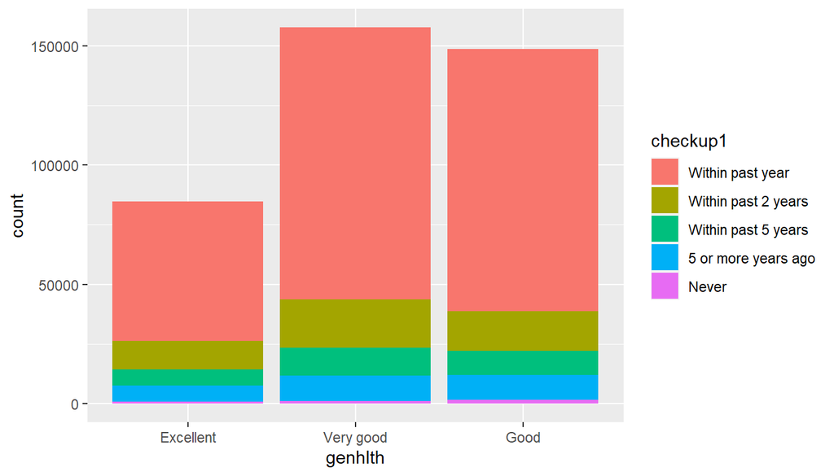

```r
brfss2013$genhlth <- as.factor(brfss2013$genhlth)
brfss2013$checkup1 <- as.factor(brfss2013$checkup1)

brfss2013_1 <- brfss2013 %>%
  filter(!is.na(genhlth),!is.na(checkup1),genhlth=="Excellent" |genhlth=="Very good" |genhlth=="Good")

ggplot(brfss2013_1, aes(x=genhlth, fill=checkup1))+
  geom_bar()
```

```r
brfss2013_1 <- brfss2013_1 %>%
  mutate(check_length=as.numeric(checkup1))

brfss2013_1 %>%
  group_by(checkup1,check_length)%>%
  summarise(count=n())
```

```
## # A tibble: 5 × 3
## # Groups:   checkup1 [5]
##   checkup1            check_length  count
##   <fct>                      <dbl>  <int>
## 1 Within past year               1 281931
## 2 Within past 2 years            2  49107
## 3 Within past 5 years            3  28605
## 4 5 or more years ago            4  27700
## 5 Never                          5   3401
```

```r
brfss2013_1 %>%
  summarise(mean_check=mean(check_length) , sd_check=sd(check_length) , med_check=median(check_length) , n=n())
```

```
##   mean_check  sd_check med_check      n
## 1   1.519575 0.9621962         1 390744
```

**Research question 2:**

What is the average **Sleep Time** of people diagnosed with **Depressive Disorder** and is it related to **Gender**? This question is of interest to me, since I want to know do people with depressive disorder sleep less or more than people without depressive disorder and if it is related to gender.

```r
brfss2013_dep <- brfss2013 %>%
  filter(!is.na(sleptim1), !is.na(sex), addepev2=="Yes")

brfss2013_not_dep <- brfss2013 %>%
  filter(!is.na(sleptim1), !is.na(sex), addepev2=="No")

brfss2013_dep %>%
  group_by(sex) %>%
  summarise(mean_sleep=mean(sleptim1),sd_sleep=sd(sleptim1),med_sleep=median(sleptim1))
```

```
## # A tibble: 2 × 4
##   sex    mean_sleep sd_sleep med_sleep
##   <fct>       <dbl>    <dbl>     <dbl>
## 1 Male         6.79     1.90         7
## 2 Female       6.92     1.82         7
```

```r
brfss2013_not_dep %>%
  group_by(sex) %>%
  summarise(mean_sleep=mean(sleptim1),sd_sleep=sd(sleptim1),med_sleep=median(sleptim1))
```

```
## # A tibble: 2 × 4
##   sex    mean_sleep sd_sleep med_sleep
##   <fct>       <dbl>    <dbl>     <dbl>
## 1 Male         7.07     1.35         7
## 2 Female       7.11     1.36         7
```

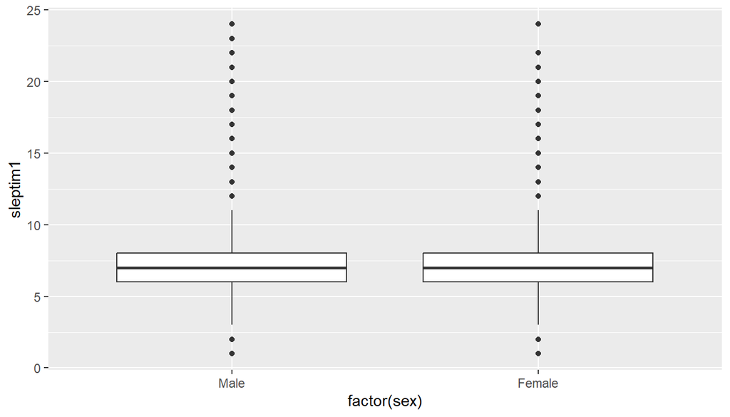

```r
ggplot(brfss2013_dep,aes(x=factor(sex),y=sleptim1)) +
  geom_boxplot()
```

**Research question 3:**

How many **Children** do people with different **Employment Status** live with in their houses and is it affected by their **Education**? This question is of interest to me, because I am interested to know how many children do people with different employment status have and is their education a **confounding variable** to this study.

```r
brfss2013_college <- brfss2013 %>%
  filter(!is.na(employ1), !is.na(children), educa=="College 4 years or more (College graduate)")

brfss2013_college <- brfss2013_college %>%
  group_by(employ1) %>%
  mutate(mean_child=mean(children), med_child=median(children))

brfss2013_college %>%
  group_by(employ1,med_child,mean_child) %>%
  summarise(count=n())
```

```
## # A tibble: 8 × 4
## # Groups:   employ1, med_child [8]
##   employ1                          med_child mean_child count
##   <fct>                                <dbl>      <dbl> <int>
## 1 Employed for wages                       0     0.750  86689
## 2 Self-employed                            0     0.606  16796
## 3 Out of work for 1 year or more           0     0.468   3046
## 4 Out of work for less than 1 year         0     0.567   3001
## 5 A homemaker                              1     1.43    7282
## 6 A student                                0     0.492   3173
## 7 Retired                                  0     0.0446 44608
## 8 Unable to work                           0     0.320   4276
```

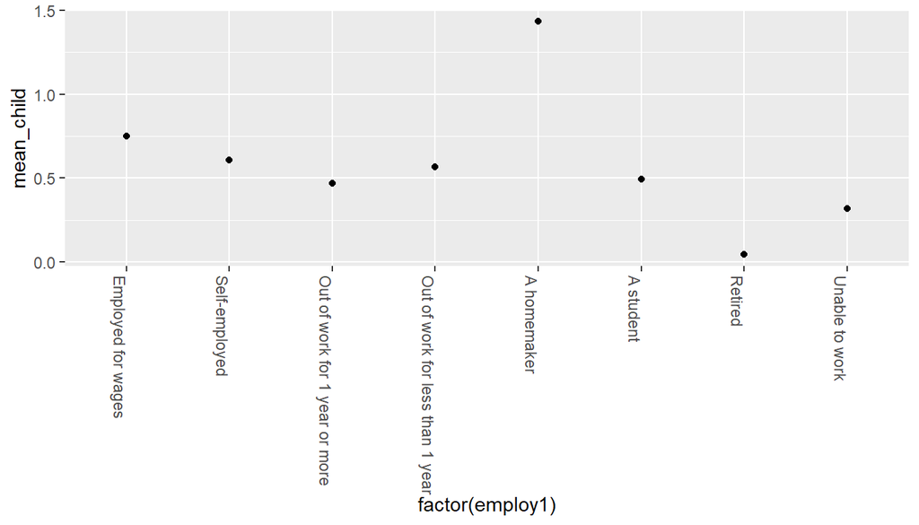

```r
ggplot(brfss2013_college,aes(x=factor(employ1),y=mean_child)) +
  geom_point() +
  theme(axis.text.x = element_text(angle = -90, hjust = 0))
```

We want to study the number of children that people with different employment status have and if it is affected by their education, so we make a new data frame of people with college degree. As shown in the plot and also in the summary statistics, there is no positive nor negative relation between **employment status** and number of **children** they live with. Although a **homemaker** seems to have more kids compared to other people. so the **education** is most likely to be a **confounding variable** in this study.(This question involves 3 variables: employ1, children, educa)